# Practical Machine Lerning - final project

PP

2023-07-13

## Background information

Using devices such as Jawbone Up, Nike FuelBand, and Fitbit it is now possible to collect a large amount of data about personal activity relatively inexpensively. These type of devices are part of the quantified self movement – a group of enthusiasts who take measurements about themselves regularly to improve their health, to find patterns in their behavior, or because they are tech geeks. One thing that people regularly do is quantify how much of a particular activity they do, but they rarely quantify how well they do it. In this project, your goal will be to use data from accelerometers on the belt, forearm, arm, and dumbell of 6 participants. They were asked to perform barbell lifts correctly and incorrectly in 5 different ways.

## Assignment

The goal of this project is to predict the manner in which several persons did the exercise. This is the “classe” variable in the training set. Other variables may used to predict with. Created report should describe how the model was built, how cross validation was used, explanation of the expected out of sample error. Created prediction model will be used to predict 20 different test cases.

## Preparation steps

Loading of needed libraries and data set.

```r
library(tidyverse)
library(caret)
library(gbm)
library(randomForest)
library(rattle)
```

```r
#library(corrplot)
set.seed(8791)

url_train <- "https://d396qusza40orc.cloudfront.net/predmachlearn/pml-training.csv"
url_test <- "https://d396qusza40orc.cloudfront.net/predmachlearn/pml-testing.csv"

download.file(url_train, destfile = "train.csv",  method = "auto")
download.file(url_test, destfile = "test.csv", method = "auto")
```

Loading data sets to R and basic analysis of dimensions

```r
training <- read.csv("train.csv")
testing <- read.csv("test.csv")

dim(training)
```

```
## [1] 19622   160
```

```r
dim(testing)
```

```
## [1]  20 160
```

Data sets consist of 160 variables, training set has 19622 observations and testing set has 20 observations.

## Cleansing of training data

As there are 160 variables and almost 20000 observations, it is helpful to analyze basic quality of of this data set and remove obvious errors and imperfections.

```r
# removing non relevant columns with time and personal data
training_cleansed <- training[,-c(1:7)]

# removing columns with NAs
na_perc <- colSums(is.na(training_cleansed)) / nrow(training_cleansed)
threshold <- 0.9
selected_columns <- na_perc < threshold
training_cleansed <- training_cleansed[, selected_columns]

# removing columns with small variance
nvz <- nearZeroVar(training_cleansed)
training_cleansed <- training_cleansed[,-nvz]

dim(training_cleansed)
```

```
## [1] 19622    53
```

There is significant reduction of variables down to 53.

## Data preparation for models

Sub setting training set for training and validation

```r
set.seed(1212)
training_cleansed$classe <- as.factor(training_cleansed$classe) # change to factor variable

inTrain <- createDataPartition(y=training_cleansed$classe, p=0.7, list=F)
train <- training_cleansed[inTrain,]
test <- training_cleansed[-inTrain,]
```

## Modelling and testing of models

The idea here is to test several models to see which perform best. Models to be tested: - Decision tree - Random forest - Gradient boosting machine

```r
set.seed(1313)
control <- trainControl(method="cv", number=2, verboseIter=F)
```

## 1. Decision tree

Model

```r
set.seed(1414)
model_trees <- train(classe~., data=train, method="rpart", trControl = control, tuneLength = 5)
```

Prediction

```r
pred_trees <- predict(model_trees, test)
cmxtrees <- confusionMatrix(pred_trees, factor(test$classe))
cmxtrees
```

```
## Confusion Matrix and Statistics
##
##           Reference
## Prediction    A    B    C    D    E
##          A 1527  457  492  414  172
##          B   26  368   29   11  128
##          C   75  125  439  136  148
##          D   41  189   66  403  172
##          E    5    0    0    0  462
##
## Overall Statistics
##
##                Accuracy : 0.5436
##                  95% CI : (0.5308, 0.5564)
##     No Information Rate : 0.2845
##     P-Value [Acc > NIR] : < 2.2e-16
##
##                   Kappa : 0.4052
##
##  Mcnemar's Test P-Value : < 2.2e-16
##
## Statistics by Class:
##
##                      Class: A Class: B Class: C Class: D Class: E
## Sensitivity            0.9122  0.32309   0.4279  0.41805  0.42699
## Specificity            0.6355  0.95912   0.9004  0.90490  0.99896
## Pos Pred Value         0.4987  0.65480   0.4756  0.46269  0.98929
## Neg Pred Value         0.9479  0.85516   0.8817  0.88811  0.88557
## Prevalence             0.2845  0.19354   0.1743  0.16381  0.18386
## Detection Rate         0.2595  0.06253   0.0746  0.06848  0.07850
## Detection Prevalence   0.5203  0.09550   0.1568  0.14800  0.07935
## Balanced Accuracy      0.7738  0.64111   0.6641  0.66147  0.71297
```

## 2. Random forest

Model

```r
set.seed(1515)
model_rf <- train(classe~., data=train, method="rf", trControl = control, tuneLength = 5)
```

Prediction

```r
pred_rf <- predict(model_rf, test)
cmxrf <- confusionMatrix(pred_rf, factor(test$classe))
cmxrf
```

```
## Confusion Matrix and Statistics
##
##           Reference
## Prediction    A    B    C    D    E
##          A 1673    3    0    0    0
##          B    1 1136    9    0    0
##          C    0    0 1011   13    1
##          D    0    0    6  948    2
##          E    0    0    0    3 1079
##
## Overall Statistics
##
##                Accuracy : 0.9935
##                  95% CI : (0.9911, 0.9954)
##     No Information Rate : 0.2845
##     P-Value [Acc > NIR] : < 2.2e-16
##
##                   Kappa : 0.9918
##
##  Mcnemar's Test P-Value : NA
##
## Statistics by Class:
##
##                      Class: A Class: B Class: C Class: D Class: E
## Sensitivity            0.9994   0.9974   0.9854   0.9834   0.9972
## Specificity            0.9993   0.9979   0.9971   0.9984   0.9994
## Pos Pred Value         0.9982   0.9913   0.9863   0.9916   0.9972
## Neg Pred Value         0.9998   0.9994   0.9969   0.9968   0.9994
## Prevalence             0.2845   0.1935   0.1743   0.1638   0.1839
## Detection Rate         0.2843   0.1930   0.1718   0.1611   0.1833
## Detection Prevalence   0.2848   0.1947   0.1742   0.1624   0.1839
## Balanced Accuracy      0.9993   0.9976   0.9912   0.9909   0.9983
```

## 3. Gradient boosting machine

Model

```r
set.seed(1616)
model_gbm <- train(classe~., data=train, method="gbm", trControl = control, tuneLength = 5, verbose = F)
```

Prediction

```r
pred_gbm <- predict(model_gbm, test)
cmxgbm <- confusionMatrix(pred_gbm, factor(test$classe))
cmxgbm
```

```
## Confusion Matrix and Statistics
##
##           Reference
## Prediction    A    B    C    D    E
##          A 1671    6    0    0    1
##          B    2 1125   10    0    8
##          C    1    8 1010    6    4
##          D    0    0    6  948    5
##          E    0    0    0   10 1064
##
## Overall Statistics
##
##                Accuracy : 0.9886
##                  95% CI : (0.9856, 0.9912)
##     No Information Rate : 0.2845
##     P-Value [Acc > NIR] : < 2.2e-16
##
##                   Kappa : 0.9856
##
##  Mcnemar's Test P-Value : NA
##
## Statistics by Class:
##
##                      Class: A Class: B Class: C Class: D Class: E
## Sensitivity            0.9982   0.9877   0.9844   0.9834   0.9834
## Specificity            0.9983   0.9958   0.9961   0.9978   0.9979
## Pos Pred Value         0.9958   0.9825   0.9815   0.9885   0.9907
## Neg Pred Value         0.9993   0.9970   0.9967   0.9968   0.9963
## Prevalence             0.2845   0.1935   0.1743   0.1638   0.1839
## Detection Rate         0.2839   0.1912   0.1716   0.1611   0.1808
## Detection Prevalence   0.2851   0.1946   0.1749   0.1630   0.1825
## Balanced Accuracy      0.9983   0.9917   0.9902   0.9906   0.9906
```

Comparison of models based on accuracy and out of sample error

```r
comparison_table <- data.frame(
  Model = c("Decision Tree", "Random Forest", "Gradient Boosting"),
  Accuracy = c(cmxtrees$overall["Accuracy"], cmxrf$overall["Accuracy"], cmxgbm$overall["Accuracy"]),
  OOS_Error = c(1 - cmxtrees$overall["Accuracy"], 1 - cmxrf$overall["Accuracy"], 1 - cmxgbm$overall["Accuracy"])
)

print(comparison_table)
```

```
##               Model  Accuracy   OOS_Error
## 1     Decision Tree 0.5435854 0.456414613
## 2     Random Forest 0.9935429 0.006457094
## 3 Gradient Boosting 0.9886151 0.011384877
```

Random Forest model performed the best among the three models. It achieved the highest accuracy, indicating better classification performance on unseen data, and the lowest out-of-sample error, suggesting robustness and generalization ability. As the predicted accuracy is over 99% it is not needed to further fine tune training process and model.

## Prediction on Test set

Prediction on unseen data using trained random forest model.

```r
pred <- predict(model_rf, testing)
print(pred)
```

```
##  [1] B A B A A E D B A A B C B A E E A B B B
## Levels: A B C D E
```

## Appendix

Graphical documentation of used models.

## 1. Decision trees

[figure not shown]

```r
fancyRpartPlot(model_trees$finalModel)
```

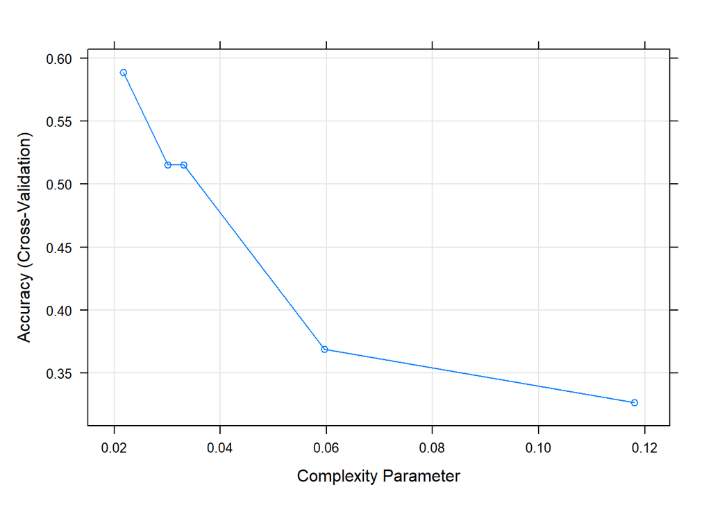

```r
plot(model_trees)
```

## 2.Random forest

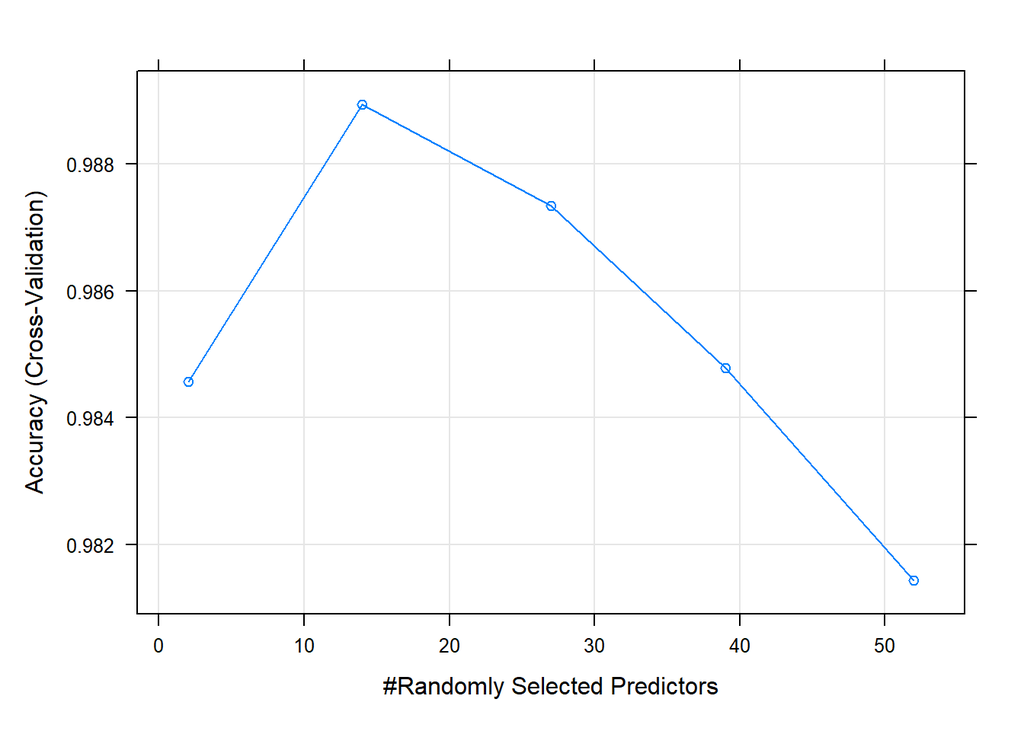

```r
plot(model_rf)
```

## 3.Gradient boosting machine

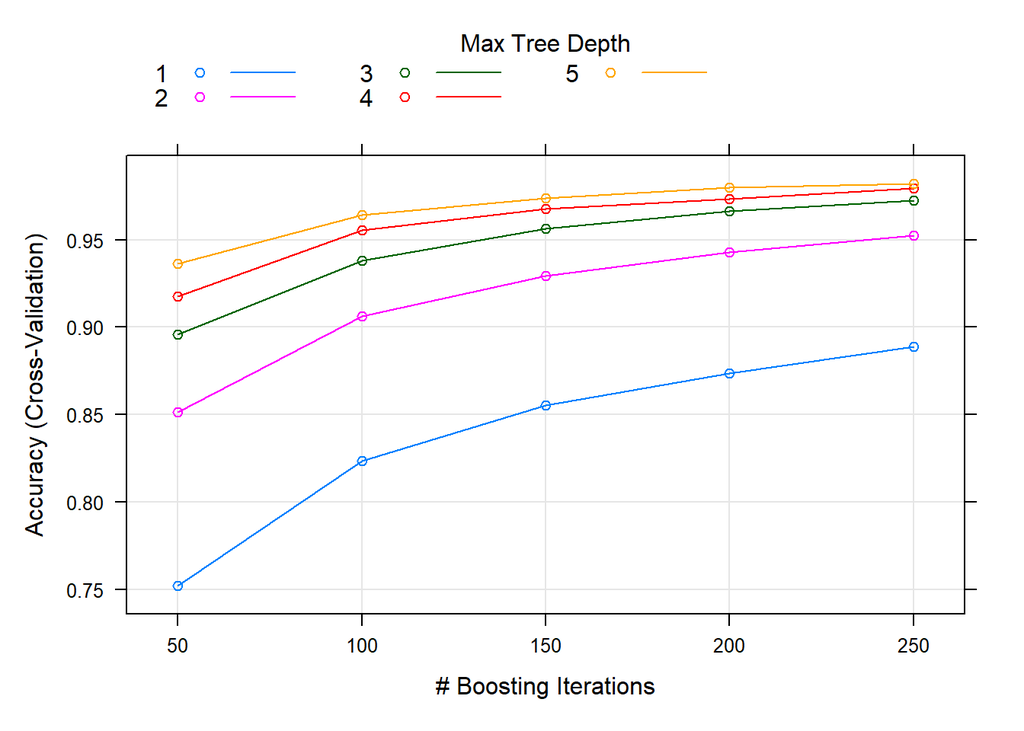

```r
plot(model_gbm)
```